# Describing Quantitative Variables (Continued)

Day 6

Claire Kelling

Carleton College  
STAT 120 - Fall 2026

## Question

What show have you watched recently?

## Today’s Topics

Logistics:

- Homework 2, Partner preferences for first short report, and Statistician of the Week due tonight!

Topics covered today:

- Quantitative Variables, Continued
- Z-scores
- Percentiles, quartiles
- Plots, understanding variability

## Shape and Summary Statistics

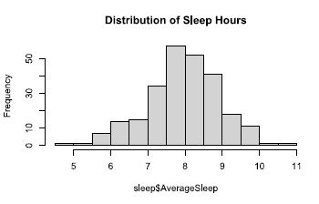

```r
sleep <- read.csv("https://math.carleton.edu/Stat120/Textbook/SleepStudy.csv")
hist(sleep$AverageSleep,
    main="Distribution of Sleep Hours")
```

- Mean and standard deviation are good summary stats of a symmetric distribution.
- Similar variation to the left and right of the mean so one measure of SD is fine.

# 95% Rule and Z scores

## 95% Rule

If a distribution of data is approximately bell-shaped, about **95% of the data should fall within two standard deviations of the mean.**

- For a **sample**: 95% of values between $\bar{y} -2 s$ and $\bar{y} + 2s$
- For a **population**: 95% of values between $\mu - 2\sigma$ and $\mu + 2\sigma$

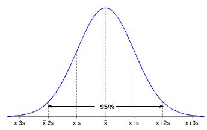

## Example: Using the 95% Rule

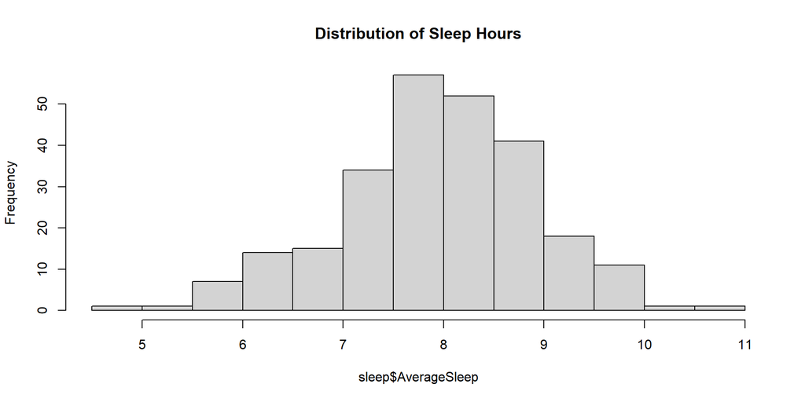

## Using the 95% Rule

**Your Turn 1**

Estimate the average hours of sleep per night from a random sample of students.

$\bar{y} =$ 8 hours (ish)

**Your Turn 2**

The standard deviation for hours of sleep per night is closest to

1. 0.5 (b) 1 (c) 2 (d) 4

(b) 1 because about 95% of the data falls between 6 and 10. The mean is about 8. So two standard deviations is approximately equal to 10-8 = 2.

**95% Rule:** If a distribution of data is approximately bell-shaped, about **95% of the data should fall within two standard deviations of the mean.**

## Standardizing Data: Z-score

**Definition: Z-score**

The z-score (or standardized value) of a data value $x$ tells us how many standard deviations the value $x$ is above or below the mean:

$$z = \frac{x - mean}{SD}$$

- E.g. if a value $x$ has $z = -1.5$ this means that the value $x$ is **1.5 standard deviations** below the mean.

## Standardizing Data

**Q:** We have a bell-shaped distribution of data ($x$’s). **Let’s standardize the whole dataset**, so now we are considering a distribution of z-scores of all the data values. 95% of all z-scores fall between what values?

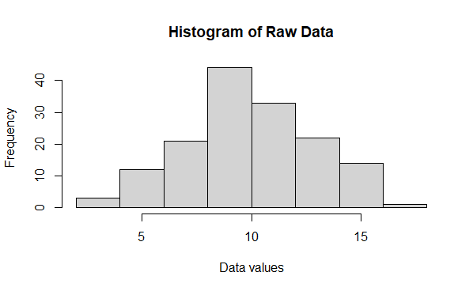

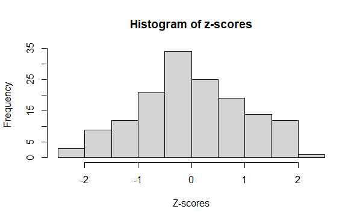

- When we standardize a dataset, it has mean 0 and SD 1 because $z = \frac{x - mean}{SD}$
- **A:** -2 and 2

## Standardizing Data: Z-score

Z-scores put measurements on a common scale

($z = \frac{x - mean}{SD}$)

**Your turn:** Which is better, an ACT score of 28 or a combined SAT score of 2100?

- ACT: $\mu = 21, \sigma = 5$
- SAT: $\mu = 1500, \sigma = 325$

$z_{ACT} = \frac{28-21}{5} = 1.4$

$z_{SAT} = \frac{2100-1500}{325} = 1.85$

**A:** SAT score because it is **1.85 SDs** above the mean SAT score while the ACT score is only 1.4 SD above the mean ACT score.

## Shape and Summary Stats: Mean/SD

Mean and standard deviation are **not** good summary stats of a **skewed** distribution.

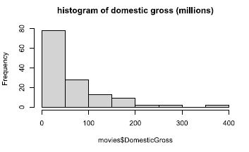

- More variation in values above mean gross than below mean gross
- One measure of variation (like SD) isn’t sufficient

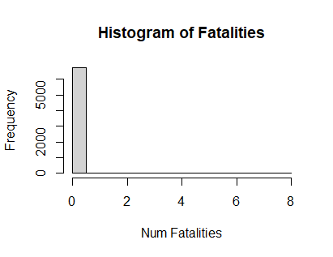

# Percentiles

## Shape and Summary Stats: Percentiles

Percentiles are good summary stats to describe a **skewed** distribution.

- The $P$th **percentile** of a distribution is the value which has $P$% of the data below it.
- The median is the 50th percentile

**ACT vs SAT, Percentiles**

The previous example used z-scores to determine whether an SAT score of 2100 or an ACT score of 28 is better

- We could also have used percentiles:
- ACT score of 28: 91st percentile (you scored better than 91% of people)
- SAT score of 2100: 97th percentile (you scored better than 97% of people!)

**Which one is better?**

## Shape and Summary Stats: Percentiles

```r
quantile(movies$DomesticGross, c(.1, .2, .5, .8, .9), na.rm = TRUE)
```

```
    10%     20%     50%     80%     90%
  4.418  13.516  37.355 100.260 167.952
```

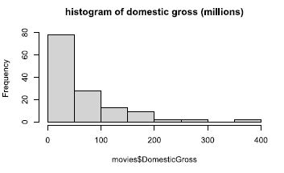

- 10th percentile is $4.4 million
- 90th percentile is $168.0 million
- The distance from the median to the 90th percentile is much greater than the from the median to the 10th percentile ($130 vs $33)

# Quartiles

## Shape and Summary Stats: Quartiles

**Quartiles** divide values in to quarters

- 1st Quartile: $Q_1$ is the 25th percentile
- 2nd Quartile: $Q_2$ is the 50th percentile (median)
- 3rd Quartile: $Q_3$ is the 75th percentile

**5-number summary** is quartiles along with min and max

- $min, Q_1, Q_2, Q_3, max$
- Can give information about *skew* of the distribution
- Look at the distance between ($Q_2$ and $Q_1$) vs ($Q_2$ and $Q_3$)
- OR the distance between ($Q_2$ and min) vs ($Q_2$ and max)
- Examples: (**which is skewed?**)
  - 5-number summary, dataset A: 1, 2.5, 3, 3.5, 5
  - 5-number summary, dataset B: 1, 2.5, 3, 7, 9

## Shape and Summary Stats: Quartiles

**Interquartile Range (IQR)**: the range of the middle 50% of values:

- $IQR =$ $Q_3 - Q_1$
- Can compute with summary() or IQR() in R

## Range

**Definition**

**Range:** Maximum - minimum

- Maximum and minimum are included in the 5 number summary

**R Command**

**range(data$quant_var)** computes the range for the variable quant_var in the data frame `data`

**Example**

```r
range(survey$Pulse)
```

```
[1]  35 130
```

The range of pulse rates for this sample of students is 35 to 130 beats per minute.

## Shape and Summary Stats: Boxplot

**Boxplot**: Visualization of 5-number summary

- Draw a numerical scale appropriate for the data (axis)
- Draw a box stretching from $Q_1$ to $Q_3$
- Divide the box with a line at the median
- Draw a line from each quartile to the most extreme data value that is **not** an outlier
- Identify each outlier individually by plotting with a symbol such as an asterisk or dot

**Outlier rule of thumb**: cases that are more extreme than

$$Q_1 - 1.5(IQR)$$

(“lower fence”)

$$Q_3 + 1.5(IQR)$$

(“upper fence”)

## Shape and Summary Stats: Boxplot

**Boxplot Example, base R**

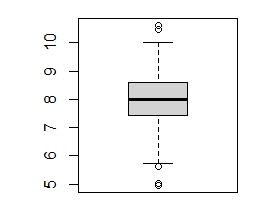

```r
boxplot(sleep$AverageSleep)
```

**Boxplot Example, ggplot**

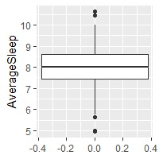

```r
ggplot(sleep) +
    geom_boxplot(aes(y = AverageSleep))
```

## Shape and Summary Stats: Boxplot

**5-number Summary in R**

```r
summary(sleep$AverageSleep)
```

```
   Min. 1st Qu.  Median    Mean 3rd Qu.    Max.
  4.950   7.430   8.000   7.966   8.590  10.620
```

- min = $4.95$, $Q_1$ = $7.43$, $m$= $8.0$, $Q_3$ = $8.59$, max = $10.62$
- $IQR = 8.59-7.43 = 1.16$
- $1.5 \times IQR = 1.5 \times 1.16 = 1.74$

**Determining Outliers from R output**

- lower “fence” = $7.43 - 1.74 = 5.69$
- upper “fence” = $8.59 + 1.74 = 10.33$

## Shape and Summary Stats: Boxplot

**5-number Summary in R**

```r
summary(sleep$AverageSleep)
```

```
   Min. 1st Qu.  Median    Mean 3rd Qu.    Max.
  4.950   7.430   8.000   7.966   8.590  10.620
```

**Determining Outliers from R output**

- lower “fence” = 7.430 - 1.74 = 5.69
- upper “fence” = 8.590 + 1.74 = 10.33

```r
which(sleep$AverageSleep < 5.69) # low outliers row number(s)
```

```
[1]   3  85 232
```

```r
which(sleep$AverageSleep > 10.33) # high outliers row number(s)
```

```
[1]  67 178
```

## Shape and Summary Stats: Side-by-side Boxplots

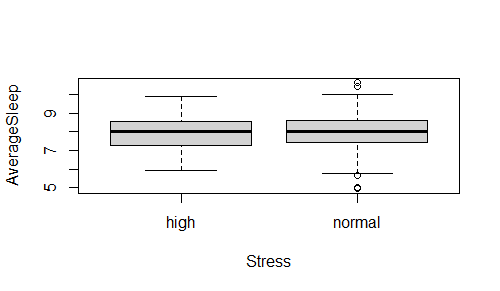

```r
boxplot(AverageSleep ~ Stress, data = sleep)
```

Very little evidence of an association between sleeping and stress in this sample.

- Both distributions are roughly symmetric
- Medians are similar
- **Tails** of the “normal” stress distribution are longer than the tails of the “high” stress group.

## Shape and Stats: Side-by-side Boxplots (ggplot)

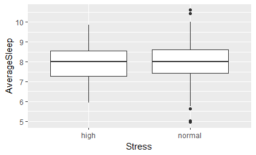

```r
ggplot(sleep, aes(x = Stress, y = AverageSleep)) + geom_boxplot()
```

Same findings as previous slide, but ggplot can be more visually appealing

Practice with Handout (with R lab manual)

Fill in the blanks!

- **Next class:** bivariate relationships